# 1st-pass analysis of Novartis DECAMP2 Nasal Brushings RNA-seq data

08 December, 2020

# Preprocessing

Based off of prior QC (“20201025_DECAMP2_Novartis_QC_Nasal.Rmd”), we have identified several poor quality samples. We will remove these samples prior to any downstream analysis.

```r
# Load library:
library(plyr)
library(SummarizedExperiment)
library(readxl)
library(dplyr)
library(ggplot2)
library(pheatmap)
library("RColorBrewer")
library(DESeq2)
library(knitr)
library(kableExtra)
library(enrichR)
library(biomaRt)

set.seed("12345")

# Load data:
se <- readRDS("/restricted/projectnb/pulmseq/Novartis/processing/work/28/da9dcb4ebb5f902c53fff1bc1ebdc2/Novartis_Gene_Expression.rds")
colnames(se) <- gsub(pattern = "_.*", "", colnames(se))

# Load annotation:

# Matches sample ID to kitnumber + Has batch info
annotManifest <- read_excel("/restricted/projectnb/pulmseq/Novartis/annotation/Novartis_RNASeq_run_manifest.xlsx")

# Matches sample ID to sample type/RIN (received from Jack, 8/24/20)
annotSampleEM0 <- read_excel("/restricted/projectnb/camplab/home/ykoga07/DECAMP/Novartis/Data/Annotation/RNA_data_for_Yusuke_08_24_20.xlsx", sheet = "EM0", skip = 2)

annotSampleEM5 <- read_excel("/restricted/projectnb/camplab/home/ykoga07/DECAMP/Novartis/Data/Annotation/RNA_data_for_Yusuke_08_24_20.xlsx", sheet = "EM5", skip = 2)

annotSampleEM6 <- read_excel("/restricted/projectnb/camplab/home/ykoga07/DECAMP/Novartis/Data/Annotation/RNA_data_for_Yusuke_08_24_20.xlsx", sheet = "EM6", skip = 2)

annotSampleEM8 <- read_excel("/restricted/projectnb/camplab/home/ykoga07/DECAMP/Novartis/Data/Annotation/RNA_data_for_Yusuke_08_24_20.xlsx", sheet = "EM8", skip = 3)

annotSampleEM15 <- read_excel("/restricted/projectnb/camplab/home/ykoga07/DECAMP/Novartis/Data/Annotation/RNA_data_for_Yusuke_08_24_20.xlsx", sheet = "EM15", skip = 3)

annotSampleEM16 <- read_excel("/restricted/projectnb/camplab/home/ykoga07/DECAMP/Novartis/Data/Annotation/RNA_data_for_Yusuke_08_24_20.xlsx", sheet = "EM16", skip = 3)

annotSampleN1 <- read_excel("/restricted/projectnb/camplab/home/ykoga07/DECAMP/Novartis/Data/Annotation/RNA_data_for_Yusuke_08_24_20.xlsx", sheet = "N1", skip = 3)

annotSampleN2 <- read_excel("/restricted/projectnb/camplab/home/ykoga07/DECAMP/Novartis/Data/Annotation/RNA_data_for_Yusuke_08_24_20.xlsx", sheet = "N2", skip = 3)

# Combine Jack's sample-based annotation file into one dataframe
annotSampleEM0 <- annotSampleEM0[, c(
  "RNA Sample ID", "DECAMP #",
  "Sample ID", "Kit Number", "Original Sample Type",
  "Isolation Date", "RIN", "DV200 (%)"
)]
colnames(annotSampleEM0) <- c(
  "RNA Sample ID", "DECAMP #",
  "Sample ID", "Kit Number", "Sample Type",
  "Isolation Date", "RIN", "DV200 (%)"
)

annotSampleEM5 <- annotSampleEM5[, c(
  "RNA Sample ID", "DECAMP #",
  "Patient ID", "Patient ID", "Sample Type",
  "Isolation Date", "RIN", "DV200 (%)"
)]
colnames(annotSampleEM5) <- c(
  "RNA Sample ID", "DECAMP #",
  "Sample ID", "Kit Number", "Sample Type",
  "Isolation Date", "RIN", "DV200 (%)"
)

annotSampleEM6 <- annotSampleEM6[, c(
  "RNA Sample ID", "DECAMP #",
  "Sample ID", "Kit Number", "Sample Type",
  "Isolation Date", "RIN", "DV200 (%)"
)]
colnames(annotSampleEM6) <- c(
  "RNA Sample ID", "DECAMP #",
  "Sample ID", "Kit Number", "Sample Type",
  "Isolation Date", "RIN", "DV200 (%)"
)

annotSampleEM8 <- annotSampleEM8[, c(
  "RNA Sample ID", "DECAMP #",
  "Sample ID", "Original Sample ID", "Sample Type",
  "Isolation Date", "RIN", "DV200 (%)"
)]
colnames(annotSampleEM8) <- c(
  "RNA Sample ID", "DECAMP #",
  "Sample ID", "Kit Number", "Sample Type",
  "Isolation Date", "RIN", "DV200 (%)"
)

annotSampleEM15 <- annotSampleEM15[, c(
  "RNA Sample ID", "DECAMP #",
  "Sample ID", "Kit Number", "Sample Type",
  "Isolation Date", "RIN", "DV200 (%)"
)]
colnames(annotSampleEM15) <- c(
  "RNA Sample ID", "DECAMP #",
  "Sample ID", "Kit Number", "Sample Type",
  "Isolation Date", "RIN", "DV200 (%)"
)

annotSampleEM16 <- annotSampleEM16[, c(
  "RNA Sample ID", "DECAMP #",
  "Sample ID", "Kit Number", "Sample Type",
  "Isolation Date", "RIN", "DV200 (%)"
)]
colnames(annotSampleEM16) <- c(
  "RNA Sample ID", "DECAMP #",
  "Sample ID", "Kit Number", "Sample Type",
  "Isolation Date", "RIN", "DV200 (%)"
)

annotSampleN1 <- annotSampleN1[, c(
  "RNA Sample ID", "DECAMP #",
  "Sample ID", "Kit Number", "Sample Type",
  "Isolation Date", "RIN", "DV200 (%)"
)]
colnames(annotSampleN1) <- c(
  "RNA Sample ID", "DECAMP #",
  "Sample ID", "Kit Number", "Sample Type",
  "Isolation Date", "RIN", "DV200 (%)"
)

annotSampleN2 <- annotSampleN2[, c(
  "RNA Sample ID", "DECAMP #",
  "Sample ID", "Kit Number", "Sample Type",
  "Isolation Date", "RIN", "DV200 (%)"
)]
colnames(annotSampleN2) <- c(
  "RNA Sample ID", "DECAMP #",
  "Sample ID", "Kit Number", "Sample Type",
  "Isolation Date", "RIN", "DV200 (%)"
)

allAnnotSamples <- ls()[grep("annotSample", ls())]
annotSample <- as.data.frame(matrix(ncol = 8))
colnames(annotSample) <- c(
  "RNA Sample ID", "DECAMP #",
  "Sample ID", "Kit Number", "Sample Type",
  "Isolation Date", "RIN", "DV200 (%)"
)
# Combine
for (x in allAnnotSamples) {
  annotSamples <- get(x)
  annotSamples$`Isolation Date` <- as.character(annotSamples$`Isolation Date`)
  annotSample <- rbind(annotSample, annotSamples)
}
annotSample <- annotSample[-which(is.na(annotSample$`RNA Sample ID`)), ]
annotSample <- annotSample[-which(is.na(annotSample$`Sample Type`)), ]

annotSample <- annotSample[-which(duplicated(annotSample$`RNA Sample ID`)), ]

# Save which samples had wrong rRNA peak when checking RIN
wrongRRNA.ix <- grep(pattern = "rong rRNA peak", annotSample$RIN)
annotSample$wrongRNAPeak <- 0
annotSample$wrongRNAPeak[wrongRRNA.ix] <- 1

# Edit RIN section to convert into numeric vector
annotSample$RIN <- gsub(pattern = "(wrong rRNA peak)", replacement = "", annotSample$RIN, fixed = TRUE)
annotSample$RIN <- gsub(pattern = "(wrong RNA peak)", replacement = "", annotSample$RIN, fixed = TRUE)
annotSample$RIN <- gsub(pattern = "(wrong rRNA peaks)", replacement = "", annotSample$RIN, fixed = TRUE)
annotSample$RIN <- gsub(pattern = "(Wrong rRNA peak)", replacement = "", annotSample$RIN, fixed = TRUE)
annotSample$RIN <- gsub(pattern = "(Wrong rRNA peaks)", replacement = "", annotSample$RIN, fixed = TRUE)
annotSample$RIN <- gsub(pattern = "\\/NA", replacement = "", annotSample$RIN)
annotSample$RIN <- gsub(pattern = ".*\\/", replacement = "", annotSample$RIN)
annotSample$RIN <- as.numeric(annotSample$RIN)
# There is a "29", probably 2.9, will ask Jack
annotSample$RIN[annotSample$RIN == 29] <- 2.9

# Consolidate nasal/bronch terms
annotSample$`Sample Type` <- gsub(pattern = ".*Bronch.*", replacement = "Bronchial Brushings", annotSample$`Sample Type`)
annotSample$`Sample Type` <- gsub(pattern = ".*Nasal.*", replacement = "Nasal Brushings", annotSample$`Sample Type`)

annotManifest <- filter(annotManifest, Run == "Run 1")
annotSample <- annotSample[annotSample$`RNA Sample ID` %in% annotManifest$Sample, ]
annotSample <- annotSample[match(annotSample$`RNA Sample ID`, annotManifest$Sample), ]

# Removing duplicate column
annotManifest$`Kit Number` <- NULL

annot <- cbind(annotManifest, annotSample)

# Clinical info:

# Matches kitnumber to randID, "Novartis_datadump"
annotDataDump2 <- read_excel("/rprojectnb/decamp/annotation/20200920/FullDECAMP2_DataDump_20200920.xlsx", sheet = "_D2CASEMAP", )

# randID to demographics info, "Novartis_datadump"
annotDataDump3 <- read_excel("/rprojectnb/decamp/annotation/20200920/FullDECAMP2_DataDump_20200920.xlsx", sheet = "_D2DEMO")

# randID to age/smoking info, "Novartis_datadump"
annotDataDump4 <- read_excel("/rprojectnb/decamp/annotation/20200920/FullDECAMP2_DataDump_20200920.xlsx", sheet = "_D2ELIGCHECK")

# randID to FEV/FVC, "Novartis_datadump"
annotDataDump5 <- read_excel("/rprojectnb/decamp/annotation/20200920/FullDECAMP2_DataDump_20200920.xlsx", sheet = "_D2PFT")
annotDataDump5 <- filter(annotDataDump5, timepoint == "Baseline Visit")

# Combine annotation info
annotA <- merge(merge(annotDataDump2, annotDataDump3, by.x = "randID", by.y = "randID"), annotDataDump4, by.x = "randID", by.y = "randID")
annotA <- merge(annotA, annotDataDump5, by.x = "randID", by.y = "randID")

# Removing patient "4796-053" as "Pacific Islander" for time being
annotA <- annotA[!(duplicated(annotA$randID)), ]

annot <- merge(annot, annotA, by.x = "Kit Number", by.y = "kitnumber", all.x = TRUE)

annotBronch <- annot[annot$`Sample Type` == "Bronchial Brushings", ]
annotNasal <- annot[annot$`Sample Type` == "Nasal Brushings", ]

uniquePatients <- length(unique(annot$`Kit Number`))

numBronch <- length(unique(annotBronch$Sample))
numNasal <- length(unique(annotNasal$Sample))

bothBronchNasal <- length(intersect(annotBronch$`Kit Number`, annotNasal$`Kit Number`))

#Steiling signature genes
steilingGenes <- read_excel("/restricted/projectnb/camplab/home/ykoga07/DECAMP/Novartis/Analysis/1stPass/Steiling_2013_Genelist.xlsx", sheet = "GeneList", col_names = FALSE)
```

There are 280 samples and 201 unique patients in the dataset. 80 are nasal samples. There are 79 patients that have both bronchial and nasal samples.

```r
# Samples flagged by Novartis as poor quality:
# flaggedByNovartis <- c(
#   "EM15-14", "EM15-31", "EM15-64", "EM15-85", "EM16-194", "EM16-195",
#   "EM16-228", "EM5-100", "EM8-112", "EM8-130", "EM8-158", "EM8-171",
#   "EM8-26", "EM8-55", "EM8-66", "N1-115", "N1-119", "N1-125",
#   "N1-139", "N1-25", "N1-40", "N1-55", "N1-63", "N1-64",
#   "N1-67", "N1-81", "N1-83", "N1-84", "N1-94", "N2-10",
#   "N2-15", "N2-18", "N2-30", "N2-31", "N2-22", "N2-28"
# )

poorQuality <- read.table("/restricted/projectnb/camplab/home/ykoga07/DECAMP/Novartis/Analysis/QC/20201026_PoorQuality_Nasal.txt")

seNasal <- se[, which(colnames(se) %in% annotNasal$`RNA Sample ID`)]
orig.num.samples <- ncol(seNasal)

#Remove:
seNasal <- seNasal[,!colnames(seNasal) %in% poorQuality$V1]
filt.num.samples <- ncol(seNasal)

annotNasal <- annotNasal[annotNasal$`RNA Sample ID` %in% colnames(se), ]

# reorder
annotNasal <- annotNasal[match(colnames(seNasal), annotNasal$`RNA Sample ID`), ]

coldataNasal <- colData(seNasal)

annotNasal$TIN <- colData(seNasal)$RSeQC_TIN_mean
```

Originally, there were 80 samples. Upon filtering, we will use 69 samples for downstream analysis.

```r
counts <- assay(seNasal)
rownames(counts) <- rowRanges(seNasal)$external_gene_id

counts <- apply(counts, 1:2, function(x) {
  return(as.integer(x))
})

# copd.status <- sapply(annotNasal$FEV_RS_PER, function(x) {
#   if (x < 80) {
#     return("COPD")
#   } else {
#     return("NO_COPD")
#   }
# })

copd.status <- c()
for(x in 1:nrow(annotNasal)){
  if(annotNasal[x, "FEV_RS_PER"] < 80 &&
     annotNasal[x, "FEV_FVC"] < 0.7){
        copd.status <- c(copd.status, "COPD")
  }else{
       copd.status <- c(copd.status, "NO_COPD")
     }
}
annotNasal$COPD_status <- as.factor(copd.status)
annotNasal$GRPB_SMK_STS <- gsub(" ", "_", annotNasal$GRPB_SMK_STS)

no.smk.status.ix <- which(is.na(annotNasal$GRPB_SMK_STS))

# counts <- counts[, -no.smk.status.ix]
# annotNasal <- annotNasal[-no.smk.status.ix, ]
```

0 samples were removed due to lack of smoker status.

```r
remove.ix <- which(colnames(counts) == "N2-28")

counts <- counts[, -remove.ix]
annotNasal <- annotNasal[-remove.ix, ]
coldataNasal <- coldataNasal[-remove.ix,]

remove.ix <- which(annotNasal$TIN < 60)
counts <- counts[, -remove.ix]
annotNasal <- annotNasal[-remove.ix, ]
coldataNasal <- coldataNasal[-remove.ix,]
```

Sample “N2-28” was removed due to abnormally low counts (n = 541048, Average: 18542574). In total, there are now 66 samples used for downstream analysis.

# Clinical annotation

General annotation data of patients were compared between those of which samples of FEV1 predicted < 80 (COPD) and FEV1 predicted > 80 (NO COPD).

```r
#Rename race
annotNasal$RACE_CAT_TXT <- gsub("Unknown","Not Reported",annotNasal$RACE_CAT_TXT)
annotNasal$RACE_CAT_TXT <- gsub("Black or Afr. American",
                                 "Black/African American",annotNasal$RACE_CAT_TXT)
annotNasal$RACE_CAT_TXT <- gsub("Native Hawaiian or Other Pacific Islander",
                                 "Pacific Islander",annotNasal$RACE_CAT_TXT)
annotNasal$RACE_CAT_TXT <- gsub("American Indian or Alaska Native",
                                 "Native American",annotNasal$RACE_CAT_TXT)
annotNasal$RACE_CAT_TXT <- as.factor(annotNasal$RACE_CAT_TXT)

annotNasal_COPD <- annotNasal[annotNasal$COPD_status == "COPD", ]

annotNasal_NO_COPD <- annotNasal[annotNasal$COPD_status == "NO_COPD", ]

lab <- c(
  rep("Retained", length(annotNasal_COPD$GRPB_SMK_STS)),
  rep("Removed", length(annotNasal_NO_COPD$GRPB_SMK_STS))
)
# AGE
mean.age <- mean(annotNasal_COPD$AGE)
sd.age <- sd(annotNasal_COPD$AGE)

age <- paste0(signif(mean.age, 3), " +/- ", signif(sd.age, 3))

mean.age.rm <- mean(annotNasal_NO_COPD$AGE)
sd.age.rm <- sd(annotNasal_NO_COPD$AGE)

age.rm <- paste0(signif(mean.age.rm, 3), " +/- ", signif(sd.age.rm, 3))

age.pvalue <- signif(wilcox.test(annotNasal_COPD$AGE, annotNasal_NO_COPD$AGE)$p.value, 3)

demo.table <- c(age, age.rm, age.pvalue)

# Gender
gstatus <- c(annotNasal_COPD$PERSON_GENDER, annotNasal_NO_COPD$PERSON_GENDER)

male.ct <- sum(annotNasal_COPD$PERSON_GENDER == "Male Gender")
male.pct <- signif(male.ct / length(annotNasal_COPD$PERSON_GENDER), 3) * 100
male <- paste0("Male: ", male.ct, "(", male.pct, "%)")

male.ct.rm <- sum(annotNasal_NO_COPD$PERSON_GENDER == "Male Gender")
male.pct.rm <- signif(male.ct.rm / length(annotNasal_NO_COPD$PERSON_GENDER), 3) * 100
male.rm <- paste0("Male: ", male.ct.rm, "(", male.pct.rm, "%)")

gender.pvalue <- signif(chisq.test(table(lab, gstatus))$p.value, 3)

demo.table <- rbind(demo.table, c(male, male.rm, gender.pvalue))

# FEV1 predicted
mean.fev1p <- mean(annotNasal_COPD$FEV_RS_PER)
sd.fev1p <- sd(annotNasal_COPD$FEV_RS_PER)

fev1p <- paste0(signif(mean.fev1p, 3), " +/- ", signif(sd.fev1p, 3))

mean.fev1p.rm <- mean(annotNasal_NO_COPD$FEV_RS_PER)
sd.fev1p.rm <- sd(annotNasal_NO_COPD$FEV_RS_PER)

fev1p.rm <- paste0(signif(mean.fev1p.rm, 3), " +/- ", signif(sd.fev1p.rm, 3))

fev1p.pvalue <- signif(wilcox.test(annotNasal_COPD$FEV_RS_PER, annotNasal_NO_COPD$FEV_RS_PER)$p.value, 3)

demo.table <- rbind(demo.table, c(fev1p, fev1p.rm, fev1p.pvalue))


# FEVFVC
mean.fevfvc <- mean(annotNasal_COPD$FEV_FVC)
sd.fevfvc <- sd(annotNasal_COPD$FEV_FVC)

fevfvc <- paste0(signif(mean.fevfvc, 3), " +/- ", signif(sd.fevfvc, 3))

mean.fevfvc.rm <- mean(annotNasal_NO_COPD$FEV_FVC)
sd.fevfvc.rm <- sd(annotNasal_NO_COPD$FEV_FVC)

fevfvc.rm <- paste0(signif(mean.fevfvc.rm, 3), " +/- ", signif(sd.fevfvc.rm, 3))

fevfvc.pvalue <- signif(wilcox.test(annotNasal_COPD$FEV_FVC, annotNasal_NO_COPD$FEV_FVC)$p.value, 3)

demo.table <- rbind(demo.table, c(fevfvc, fevfvc.rm, fevfvc.pvalue))

# TIN
mean.tin <- mean(annotNasal_COPD$TIN)
sd.tin <- sd(annotNasal_COPD$TIN)

tin <- paste0(signif(mean.tin, 3), " +/- ", signif(sd.tin, 3))

mean.tin.rm <- mean(annotNasal_NO_COPD$TIN)
sd.tin.rm <- sd(annotNasal_NO_COPD$TIN)

tin.rm <- paste0(signif(mean.tin.rm, 3), " +/- ", signif(sd.tin.rm, 3))

tin.pvalue <- signif(wilcox.test(annotNasal_COPD$TIN, annotNasal_NO_COPD$TIN)$p.value, 3)

demo.table <- rbind(demo.table, c(tin, tin.rm, tin.pvalue))

# Smoking Status
smk <- c(annotNasal_COPD$GRPB_SMK_STS, annotNasal_NO_COPD$GRPB_SMK_STS)

annotNasal_COPD$GRPB_SMK_STS <- gsub(" ", "_", annotNasal_COPD$GRPB_SMK_STS)
annotNasal_NO_COPD$GRPB_SMK_STS <- gsub(" ", "_", annotNasal_NO_COPD$GRPB_SMK_STS)

smkstatus.na <- sum(is.na(annotNasal_COPD$GRPB_SMK_STS == "Current_Smoker"))

smkstatus.ct <- sum(annotNasal_COPD[!is.na(annotNasal_COPD$GRPB_SMK_STS), ]$GRPB_SMK_STS == "Current_Smoker")
smkstatus.pct <- signif(smkstatus.ct / nrow(annotNasal_COPD[!is.na(annotNasal_COPD$GRPB_SMK_STS), ]), 3) * 100
smkstatus <- paste0("Current: ", smkstatus.ct, "(", smkstatus.pct, "%)")

smkstatus.ct.rm <- sum(annotNasal_NO_COPD$GRPB_SMK_STS == "Current_Smoker")
smkstatus.pct.rm <- signif(smkstatus.ct.rm / length(annotNasal_NO_COPD$GRPB_SMK_STS), 3) * 100
smkstatus.rm <- paste0("Current: ", smkstatus.ct.rm, "(", smkstatus.pct.rm, "%)")

smkstatus.pvalue <- signif(chisq.test(table(lab, smk))$p.value, 3)

demo.table <- rbind(demo.table, c(smkstatus, smkstatus.rm, smkstatus.pvalue))

rownames(demo.table) <- c("Age", "Gender", "FEV1 Predicted (%)" , "FEV1/FVC", "TIN","Smoking Status")
colnames(demo.table) <- c("COPD", "NO COPD", "p-value")

copd.race.table <- as.data.frame(table(annotNasal_COPD$RACE_CAT_TXT))
rownames(copd.race.table) <- copd.race.table$Var1
copd.race.table$Var1 <- NULL

nocopd.race.table <- as.data.frame(table(annotNasal_NO_COPD$RACE_CAT_TXT))
rownames(nocopd.race.table) <- nocopd.race.table$Var1
nocopd.race.table$Var1 <- NULL

race.table <- cbind(copd.race.table, nocopd.race.table)
race.table <- race.table[c(5, 1, 2, 4, 3),]
colnames(race.table) <- c("COPD", "NO COPD")
race.table$`p-value` <- c(signif(chisq.test(race.table)$p.value, 3),
                        rep("", nrow(race.table) - 1))

blank <- as.data.frame(matrix("", ncol = 3))
colnames(blank) <- c("COPD", "NO COPD", "p-value")
rownames(blank) <- "Race"

race.table <- rbind(blank,race.table)

demo.table <- rbind(demo.table, race.table)

demo.table %>%
  knitr::kable(
    format = "html", align = rep("c", ncol(demo.table) + 1),
    row.names = TRUE
  ) %>%
  add_indent(c(7:12)) %>%
  kableExtra::kable_styling()
```

|  | COPD | NO COPD | p-value |
| --- | --- | --- | --- |
| Age | 63.6 +/- 6.51 | 61.2 +/- 5.59 | 0.129 |
| Gender | Male: 28(82.4%) | Male: 22(68.8%) | 0.317 |
| FEV1 Predicted (%) | 60.2 +/- 12.5 | 82 +/- 13 | 5.65e-08 |
| FEV1/FVC | 0.546 +/- 0.0993 | 0.76 +/- 0.0578 | 2.95e-12 |
| TIN | 68.3 +/- 2.45 | 69.8 +/- 1.99 | 0.00495 |
| Smoking Status | Current: 13(38.2%) | Current: 12(37.5%) | 1 |
| Race |  |  |  |
| White | 26 | 21 | 0.445 |
| Black or African American | 7 | 9 |  |
| Native American | 0 | 1 |  |
| Pacific Islander | 1 | 0 |  |
| Not Reported | 0 | 1 |  |

# Differential Expression

## Using COPD as continuous variable

Differential expression was conducted using the DESeq2 package to compare patients with low FEV1pred values (< 80) and high values. The FEV1 predicted values are used as a proxy for COPD status. Expected counts outputted from the RSEM algorithm was taken for DESeq2.

```r
dds <- DESeqDataSetFromMatrix(
  countData = counts,
  colData = annotNasal,
  design = ~GRPB_SMK_STS + AGE + TIN + FEV_RS_PER
)

dds$GRPB_SMK_STS <- relevel(dds$GRPB_SMK_STS, ref = "Former_Smoker")

keep <- rowSums(counts(dds)) >= 10
dds <- dds[keep, ]
dds <- DESeq(dds)
res <- results(dds)

res$nLogPVal <- -log10(res$padj)

resOrdered <- res[order(res$pvalue), ]
resOrdered <- as.data.frame(resOrdered)

#For pre-ranked GSEA
resOrderLFC <- res[order(res$log2FoldChange), ]
resOrderLFC <- resOrderLFC[,2, drop = F]
resOrderLFC$Gene <- rownames(resOrderLFC)
resOrderLFC <- resOrderLFC[,c(2,1)]
#write.table(resOrderLFC, "20201104_GSEA_Rankedlist_FEVPred_Bronch.rnk", sep = "\t", col.names = T, row.names = F)

resSig <- resOrdered[resOrdered$padj < 0.05,]
resSig <- resSig[!is.na(resSig$padj),]

resSig <- resSig[order(resSig$log2FoldChange), ]
numSig <- nrow(resSig)

resSigUp <- resSig[head(order(resSig$log2FoldChange, decreasing = T), 50),]
resSigDown <- resSig[head(order(resSig$log2FoldChange, decreasing = F), 50),]
resSig2 <- rbind(resSigDown, resSigUp)
numUp <- nrow(resSig[resSig$log2FoldChange > 0.5, ])
numDown <- nrow(resSig[resSig$log2FoldChange < -0.5, ])

resSig3 <- resSig[abs(resSig$log2FoldChange) > 0.01,]
```

A total of 6 genes passed the FDR < 0.05 threshold.

#### Volcano plot

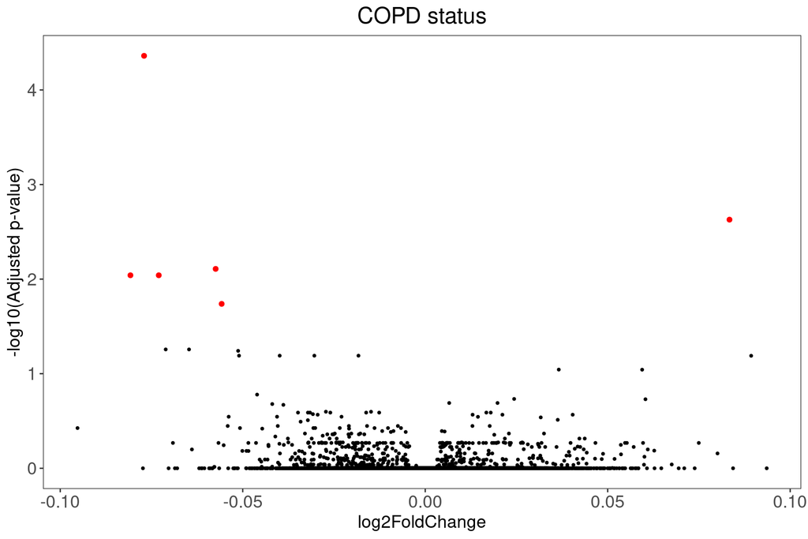

```r
ggplot(resOrdered, aes(x = log2FoldChange, y = nLogPVal)) +
  geom_point(size = 0.75) +
  ggplot2::theme_bw() +
  ggplot2::theme(
    panel.grid.major = ggplot2::element_blank(),
    panel.grid.minor = ggplot2::element_blank(),
    axis.text = ggplot2::element_text(size = 14),
    axis.title = ggplot2::element_text(size = 14)
  ) +
  ggplot2::theme(legend.title = ggplot2::element_text(size = 15), legend.text = ggplot2::element_text(size = 13)) +
  ggplot2::guides(
    colour =
      ggplot2::guide_legend(override.aes = list(size = 2))
  ) +
  geom_point(data = resSig, aes(x = log2FoldChange, y = nLogPVal), color = "Red")+
  ggplot2::labs(y = "-log10(Adjusted p-value)") +
  ggplot2::ggtitle(label = "COPD status") +
  ggplot2::theme(plot.title = ggplot2::element_text(
    hjust = 0.5,
    size = 18
  ))
```

#### Heatmap

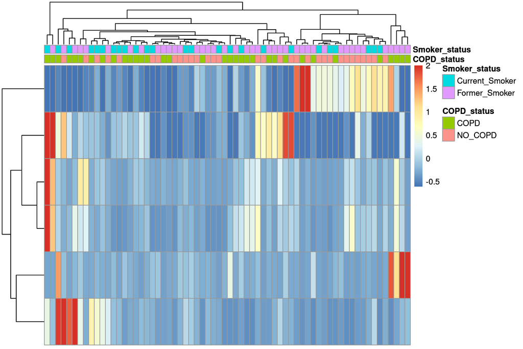

```r
counts.z <- t(scale(t(counts)))
counts.z.trim <- counts.z

counts.z.trim[counts.z.trim < -2] <- -2
counts.z.trim[counts.z.trim > 2] <- 2

counts.z.trim <- counts.z.trim[rownames(counts.z.trim) %in% rownames(resSig3),]

COPD_status <- annotNasal$COPD_status
Smoker_status <- annotNasal$GRPB_SMK_STS

annotation_col <- data.frame(COPD_status, Smoker_status)
rownames(annotation_col) <- colnames(counts.z.trim)
callback <- function(hc, mat) {
  sv <- svd(t(mat))$v[, 1]
  dend <- reorder(as.dendrogram(hc), wts = sv)
  as.hclust(dend)
}

out <- pheatmap(counts.z.trim,
  color = colorRampPalette(rev(brewer.pal(n = 7, name = "RdYlBu")))(100),
  annotation_col = annotation_col,
  legend = T,
  show_rownames = F,
  show_colnames = F,
  fontsize_row = 9,
  cluster_rows = TRUE,
  cluster_cols = TRUE
)

out
```

#### Tables

##### Top 20 most upregulated in higher FEV1 predicted

```r
# resSigUp <- res[head(order(res$log2FoldChange, decreasing = T), 20),]
resSigUp <- resSigUp[,c(2,5,6)]
colnames(resSigUp) <- c("Log2FC", "P-value", "Adj. P-value")
resSigUp %>%
  knitr::kable(
    format = "html", align = rep("c", ncol(resSig) + 1),
    row.names = TRUE
  ) %>%
  kableExtra::kable_styling() %>%
  kableExtra::scroll_box(height = "300px")
```

|  | Log2FC | P-value | Adj. P-value |
| --- | --- | --- | --- |
| COL10A1 | 0.0833675 | 1.0e-07 | 0.0023514 |
| CXCL10 | -0.0557745 | 3.0e-06 | 0.0182725 |
| DNAJC12 | -0.0574246 | 6.0e-07 | 0.0077954 |
| SLC9A3 | -0.0730067 | 1.2e-06 | 0.0091083 |
| CXCL9 | -0.0770331 | 0.0e+00 | 0.0000436 |
| RP11-291B21.2 | -0.0807716 | 1.0e-06 | 0.0091083 |

##### Top 20 most downregulated in higher FEV1 predicted

```r
# resSigDown <- res[head(order(res$log2FoldChange, decreasing = F), 20),]
resSigDown <- resSigDown[,c(2,5,6)]
colnames(resSigDown) <- c("Log2FC", "P-value", "Adj. P-value")
resSigDown %>%
  knitr::kable(
    format = "html", align = rep("c", ncol(resSig) + 1),
    row.names = TRUE
  ) %>%
  kableExtra::kable_styling() %>%
  kableExtra::scroll_box(height = "300px")
```

|  | Log2FC | P-value | Adj. P-value |
| --- | --- | --- | --- |
| RP11-291B21.2 | -0.0807716 | 1.0e-06 | 0.0091083 |
| CXCL9 | -0.0770331 | 0.0e+00 | 0.0000436 |
| SLC9A3 | -0.0730067 | 1.2e-06 | 0.0091083 |
| DNAJC12 | -0.0574246 | 6.0e-07 | 0.0077954 |
| CXCL10 | -0.0557745 | 3.0e-06 | 0.0182725 |
| COL10A1 | 0.0833675 | 1.0e-07 | 0.0023514 |

### Model used: ~Smoking status + Age + TIN + FEV1 predicted

```r
dds <- DESeqDataSetFromMatrix(
  countData = counts,
  colData = annotNasal,
  design = ~GRPB_SMK_STS + AGE + TIN + FEV_RS_PER
)

dds$GRPB_SMK_STS <- relevel(dds$GRPB_SMK_STS, ref = "Former_Smoker")

keep <- rowSums(counts(dds)) >= 10
dds <- dds[keep, ]
dds <- DESeq(dds)
res <- results(dds)

res$nLogPVal <- -log10(res$padj)

resOrdered <- res[order(res$pvalue), ]
resOrdered <- as.data.frame(resOrdered)

#For pre-ranked GSEA
resOrderLFC <- res[order(res$log2FoldChange), ]
resOrderLFC <- resOrderLFC[,2, drop = F]
resOrderLFC$Gene <- rownames(resOrderLFC)
resOrderLFC <- resOrderLFC[,c(2,1)]
#write.table(resOrderLFC, "20201104_GSEA_Rankedlist_FEVPred_Bronch.rnk", sep = "\t", col.names = T, row.names = F)

resSig <- resOrdered[resOrdered$padj < 0.05,]
resSig <- resSig[!is.na(resSig$padj),]

resSig <- resSig[order(resSig$log2FoldChange), ]
numSig <- nrow(resSig)

resSigUp <- resSig[head(order(resSig$log2FoldChange, decreasing = T), 50),]
resSigDown <- resSig[head(order(resSig$log2FoldChange, decreasing = F), 50),]
resSig2 <- rbind(resSigDown, resSigUp)
# numUp <- nrow(resSig[resSig$log2FoldChange > 0.5, ])
# numDown <- nrow(resSig[resSig$log2FoldChange < -0.5, ])

resSig3 <- resSig[abs(resSig$log2FoldChange) > 0.01,]
```

A total of 6 genes were passed the adjusted p-value < 0.05 threshold.

#### Volcano plot

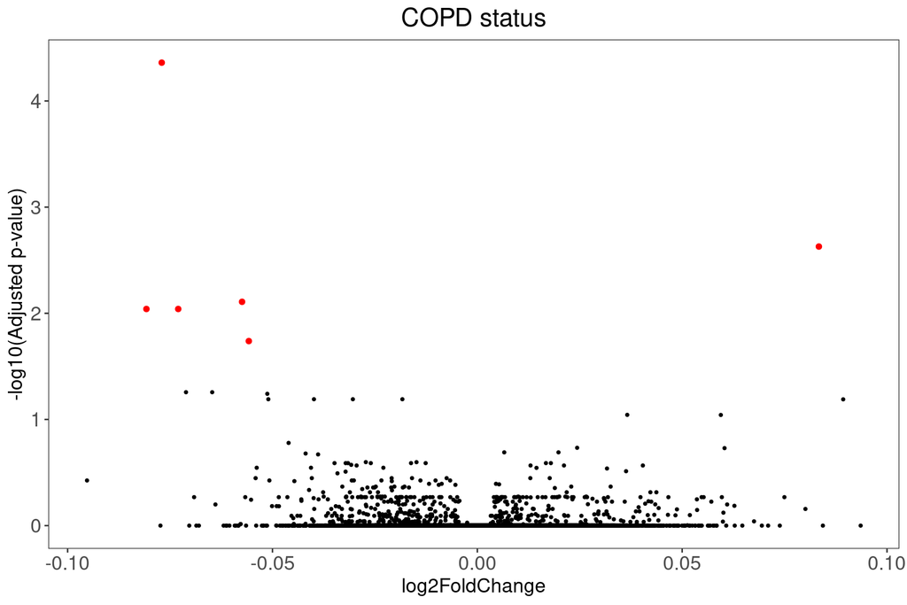

```r
ggplot(resOrdered, aes(x = log2FoldChange, y = nLogPVal)) +
  geom_point(size = 0.75) +
  ggplot2::theme_bw() +
  ggplot2::theme(
    panel.grid.major = ggplot2::element_blank(),
    panel.grid.minor = ggplot2::element_blank(),
    axis.text = ggplot2::element_text(size = 14),
    axis.title = ggplot2::element_text(size = 14)
  ) +
  ggplot2::theme(legend.title = ggplot2::element_text(size = 15), legend.text = ggplot2::element_text(size = 13)) +
  ggplot2::guides(
    colour =
      ggplot2::guide_legend(override.aes = list(size = 2))
  ) +
  geom_point(data = resSig, aes(x = log2FoldChange, y = nLogPVal), color = "Red")+
  ggplot2::labs(y = "-log10(Adjusted p-value)") +
  ggplot2::ggtitle(label = "COPD status") +
  ggplot2::theme(plot.title = ggplot2::element_text(
    hjust = 0.5,
    size = 18
  ))
```

### Tables

#### Top 20 most upregulated in higher FEV1 predicted

```r
# resSigUp <- res[head(order(res$log2FoldChange, decreasing = T), 20),]
resSigUp <- resSigUp[,c(2,5,6)]
colnames(resSigUp) <- c("Log2FC", "P-value", "Adj. P-value")
resSigUp %>%
  knitr::kable(
    format = "html", align = rep("c", ncol(resSig) + 1),
    row.names = TRUE
  ) %>%
  kableExtra::kable_styling() %>%
  kableExtra::scroll_box(height = "300px")
```

|  | Log2FC | P-value | Adj. P-value |
| --- | --- | --- | --- |
| COL10A1 | 0.0833675 | 1.0e-07 | 0.0023514 |
| CXCL10 | -0.0557745 | 3.0e-06 | 0.0182725 |
| DNAJC12 | -0.0574246 | 6.0e-07 | 0.0077954 |
| SLC9A3 | -0.0730067 | 1.2e-06 | 0.0091083 |
| CXCL9 | -0.0770331 | 0.0e+00 | 0.0000436 |
| RP11-291B21.2 | -0.0807716 | 1.0e-06 | 0.0091083 |

#### Top 20 most downregulated in higher FEV1 predicted

```r
# resSigDown <- res[head(order(res$log2FoldChange, decreasing = F), 20),]
resSigDown <- resSigDown[,c(2,5,6)]
colnames(resSigDown) <- c("Log2FC", "P-value", "Adj. P-value")
resSigDown %>%
  knitr::kable(
    format = "html", align = rep("c", ncol(resSig) + 1),
    row.names = TRUE
  ) %>%
  kableExtra::kable_styling() %>%
  kableExtra::scroll_box(height = "300px")
```

|  | Log2FC | P-value | Adj. P-value |
| --- | --- | --- | --- |
| RP11-291B21.2 | -0.0807716 | 1.0e-06 | 0.0091083 |
| CXCL9 | -0.0770331 | 0.0e+00 | 0.0000436 |
| SLC9A3 | -0.0730067 | 1.2e-06 | 0.0091083 |
| DNAJC12 | -0.0574246 | 6.0e-07 | 0.0077954 |
| CXCL10 | -0.0557745 | 3.0e-06 | 0.0182725 |
| COL10A1 | 0.0833675 | 1.0e-07 | 0.0023514 |

#### Top 20 most upregulated in higher TIN

```r
res <- results(dds, name = "TIN")
resOrdered <- res[order(res$pvalue), ]
resOrdered <- as.data.frame(resOrdered)

resSig <- resOrdered[resOrdered$padj < 0.05,]
resSig <- resSig[!is.na(resSig$padj),]

resSig <- resSig[order(resSig$log2FoldChange), ]
numSig <- nrow(resSig)

resSigUp <- resSig[head(order(resSig$log2FoldChange, decreasing = T), 50),]
resSigDown <- resSig[head(order(resSig$log2FoldChange, decreasing = F), 50),]

resSigUp <- resSigUp[,c(2,5,6)]
colnames(resSigUp) <- c("Log2FC", "P-value", "Adj. P-value")
resSigUp %>%
  knitr::kable(
    format = "html", align = rep("c", ncol(resSig) + 1),
    row.names = TRUE
  ) %>%
  kableExtra::kable_styling() %>%
  kableExtra::scroll_box(height = "300px")
```

|  | Log2FC | P-value | Adj. P-value |
| --- | --- | --- | --- |
| DYX1C1-CCPG1 | 0.8224157 | 0.0185519 | 0.0463538 |
| CD200R1L | 0.5989939 | 0.0000652 | 0.0003636 |
| SNORA40.1 | 0.5795223 | 0.0000001 | 0.0000019 |
| RP11-424M24.5 | 0.5689223 | 0.0000010 | 0.0000096 |
| CATSPERD | 0.5332284 | 0.0110165 | 0.0298420 |
| C1orf189 | 0.5295801 | 0.0094774 | 0.0262750 |
| RP11-292F9.1 | 0.5218318 | 0.0001650 | 0.0008178 |
| HSPD1P16 | 0.5205857 | 0.0000250 | 0.0001590 |
| SNORD55 | 0.5134876 | 0.0000000 | 0.0000001 |
| RP11-353J17.3 | 0.5134579 | 0.0000086 | 0.0000628 |
| CCL15-CCL14 | 0.5084384 | 0.0180482 | 0.0452977 |
| RP11-534P19.1 | 0.4962312 | 0.0000114 | 0.0000801 |
| PAGE5 | 0.4959353 | 0.0000001 | 0.0000011 |
| UCN3 | 0.4952879 | 0.0069367 | 0.0202188 |
| RNU1-94P | 0.4864715 | 0.0000166 | 0.0001110 |
| SEC14L3 | 0.4791492 | 0.0000006 | 0.0000059 |
| RP11-301N24.3 | 0.4763709 | 0.0000045 | 0.0000358 |
| RP11-356K23.2 | 0.4742029 | 0.0000027 | 0.0000237 |
| RP11-701B16.2 | 0.4702074 | 0.0000391 | 0.0002337 |
| DUXAP1 | 0.4671485 | 0.0000000 | 0.0000006 |
| ADAMTS7P2 | 0.4665530 | 0.0076795 | 0.0219991 |
| RP11-351N6.1 | 0.4651284 | 0.0001636 | 0.0008120 |
| NXF2B | 0.4617799 | 0.0008417 | 0.0033340 |
| RP11-371A19.2 | 0.4611249 | 0.0000065 | 0.0000498 |
| HNRNPCP7 | 0.4587288 | 0.0001683 | 0.0008324 |
| LRRC63 | 0.4579588 | 0.0000055 | 0.0000430 |
| RP11-138H8.6 | 0.4578008 | 0.0000062 | 0.0000473 |
| RP11-232C2.1 | 0.4573670 | 0.0000551 | 0.0003158 |
| OR7E154P | 0.4559145 | 0.0010834 | 0.0041359 |
| HHLA2 | 0.4546694 | 0.0000005 | 0.0000051 |
| RP11-413P11.1 | 0.4542987 | 0.0000060 | 0.0000464 |
| AC007875.2 | 0.4535311 | 0.0005657 | 0.0023560 |
| RP5-926E3.1 | 0.4512644 | 0.0000159 | 0.0001070 |
| RP4-564M11.2 | 0.4507073 | 0.0001455 | 0.0007349 |
| SNORA63 | 0.4497885 | 0.0001204 | 0.0006210 |
| RP11-296L22.8 | 0.4487638 | 0.0000006 | 0.0000060 |
| RP11-431D12.1 | 0.4487366 | 0.0002059 | 0.0009899 |
| AC104532.2 | 0.4485803 | 0.0011862 | 0.0044676 |
| RP11-247L20.4 | 0.4485208 | 0.0000004 | 0.0000040 |
| MRPL42P6 | 0.4481450 | 0.0000006 | 0.0000067 |
| IGHG3 | 0.4448800 | 0.0009297 | 0.0036299 |
| C1QL2 | 0.4446257 | 0.0000101 | 0.0000724 |
| PTP4A1P6 | 0.4444808 | 0.0000013 | 0.0000127 |
| CWH43 | 0.4421382 | 0.0000000 | 0.0000004 |
| CNTN4-AS1 | 0.4420750 | 0.0000071 | 0.0000535 |
| Metazoa_SRP.3 | 0.4409425 | 0.0000006 | 0.0000068 |
| AC002064.5 | 0.4395707 | 0.0000000 | 0.0000000 |
| RPE65 | 0.4381795 | 0.0007847 | 0.0031311 |
| CCDC175 | 0.4377207 | 0.0000000 | 0.0000004 |
| RP11-150O12.3 | 0.4374027 | 0.0000030 | 0.0000257 |

#### Top 20 most downregulated in higher TIN

```r
# resSigDown <- res[head(order(res$log2FoldChange, decreasing = F), 20),]
resSigDown <- resSigDown[,c(2,5,6)]
colnames(resSigDown) <- c("Log2FC", "P-value", "Adj. P-value")
resSigDown %>%
  knitr::kable(
    format = "html", align = rep("c", ncol(resSig) + 1),
    row.names = TRUE
  ) %>%
  kableExtra::kable_styling() %>%
  kableExtra::scroll_box(height = "300px")
```

|  | Log2FC | P-value | Adj. P-value |
| --- | --- | --- | --- |
| PRR9 | -0.6989447 | 0.0000000 | 0.0000005 |
| REXO1L1P | -0.6869242 | 0.0000000 | 0.0000002 |
| DMRTC2 | -0.6779896 | 0.0000000 | 0.0000001 |
| RP11-126O22.1 | -0.6661419 | 0.0000057 | 0.0000444 |
| RP11-846F4.5 | -0.6652130 | 0.0000578 | 0.0003289 |
| AC105342.1 | -0.6617927 | 0.0000441 | 0.0002602 |
| RP5-892K4.1 | -0.6534795 | 0.0000000 | 0.0000001 |
| CTD-2311B13.7 | -0.6521268 | 0.0000009 | 0.0000087 |
| RP4-576H24.4 | -0.6473260 | 0.0000104 | 0.0000739 |
| RP11-210M15.1 | -0.6332966 | 0.0000004 | 0.0000045 |
| ACSM2B | -0.6324514 | 0.0000001 | 0.0000016 |
| MMP8 | -0.6294432 | 0.0000012 | 0.0000117 |
| FBXO40 | -0.6233441 | 0.0000363 | 0.0002199 |
| LSMEM2 | -0.6221544 | 0.0000003 | 0.0000034 |
| GABRA4 | -0.6220854 | 0.0000004 | 0.0000041 |
| AC068491.3 | -0.6188598 | 0.0000644 | 0.0003596 |
| RBFOX3 | -0.6156966 | 0.0004230 | 0.0018323 |
| RP11-76E17.4 | -0.6138923 | 0.0000008 | 0.0000084 |
| CTA-929C8.6 | -0.6129901 | 0.0000013 | 0.0000125 |
| NEFM | -0.6117360 | 0.0000000 | 0.0000000 |
| BMP6 | -0.6095804 | 0.0000000 | 0.0000000 |
| NCR1 | -0.6095586 | 0.0000000 | 0.0000000 |
| RP11-587P21.2 | -0.6084224 | 0.0000000 | 0.0000000 |
| SPATA31E3P | -0.6083413 | 0.0000218 | 0.0001409 |
| PRAMEF1 | -0.6070023 | 0.0031327 | 0.0102896 |
| CTD-3023J11.2 | -0.6016308 | 0.0000000 | 0.0000000 |
| PABPC1P8 | -0.6002287 | 0.0002368 | 0.0011136 |
| RP11-184M15.1 | -0.5955809 | 0.0068440 | 0.0199839 |
| TNP2 | -0.5950842 | 0.0000241 | 0.0001544 |
| RP11-266L9.2 | -0.5947222 | 0.0001115 | 0.0005813 |
| TEDDM1 | -0.5945092 | 0.0000003 | 0.0000037 |
| AC007126.1 | -0.5934894 | 0.0002257 | 0.0010699 |
| NANOGP1 | -0.5900929 | 0.0000040 | 0.0000326 |
| SLITRK3 | -0.5867286 | 0.0002700 | 0.0012454 |
| AIFM1P1 | -0.5861530 | 0.0000201 | 0.0001316 |
| CASP14 | -0.5831227 | 0.0000006 | 0.0000066 |
| CD300LD | -0.5826335 | 0.0000482 | 0.0002807 |
| DDX10P2 | -0.5825061 | 0.0001607 | 0.0008001 |
| HHLA1 | -0.5799517 | 0.0000002 | 0.0000027 |
| GPR26 | -0.5791056 | 0.0001602 | 0.0007980 |
| RP11-244H18.4 | -0.5786109 | 0.0110140 | 0.0298376 |
| RP11-476C8.2 | -0.5785356 | 0.0000000 | 0.0000000 |
| GPC5 | -0.5766013 | 0.0000002 | 0.0000025 |
| RP11-255H23.4 | -0.5755310 | 0.0000000 | 0.0000001 |
| DLL4 | -0.5751255 | 0.0000000 | 0.0000000 |
| IL36B | -0.5745953 | 0.0000010 | 0.0000100 |
| RP11-753D20.4 | -0.5745226 | 0.0000133 | 0.0000917 |
| LINC00940 | -0.5738139 | 0.0000581 | 0.0003301 |
| SIRPD | -0.5737001 | 0.0000000 | 0.0000000 |
| MAFA | -0.5721260 | 0.0000000 | 0.0000002 |

## Using COPD as categorical variable

Differential expression was conducted using the DESeq2 package to compare patients with low FEV1pred values (< 80) and high values, where all samples with low FEV1pred is considered to be COPD. Expected counts outputted from the RSEM algorithm was taken for DESeq2.

Model used: ~Smoking status + Age + COPD status

```r
dds <- DESeqDataSetFromMatrix(
  countData = counts,
  colData = annotNasal,
  design = ~GRPB_SMK_STS + AGE + COPD_status
)

dds$GRPB_SMK_STS <- relevel(dds$GRPB_SMK_STS, ref = "Former_Smoker")

keep <- rowSums(counts(dds)) >= 10
dds <- dds[keep, ]
dds <- DESeq(dds)
res <- results(dds)

res$nLogPVal <- -log10(res$padj)

resOrdered <- res[order(res$pvalue), ]
resOrdered <- as.data.frame(resOrdered)

#For pre-ranked GSEA
resOrderLFC <- res[order(res$log2FoldChange), ]
resOrderLFC <- resOrderLFC[,2, drop = F]
resOrderLFC$Gene <- rownames(resOrderLFC)
resOrderLFC <- resOrderLFC[,c(2,1)]

# write.table(resOrderLFC, "20201111_GSEA_Rankedlist_COPDstatus_Nasal.rnk", sep = "\t", col.names = T, row.names = F)

resOrdered <- resOrdered[abs(resOrdered$log2FoldChange) < 10,]
resSig <- resOrdered %>%
  filter(padj < 0.05) %>%
  filter(abs(log2FoldChange) > 0.5)
numSig <- nrow(resSig)
numUp <- nrow(resSig[resSig$log2FoldChange > 0.5, ])
numDown <- nrow(resSig[resSig$log2FoldChange < -0.5, ])
```

### Volcano plot

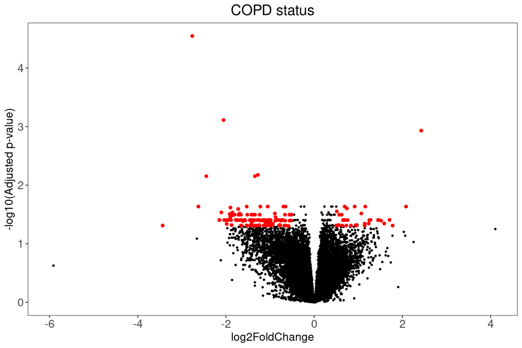

```r
ggplot(resOrdered, aes(x = log2FoldChange, y = nLogPVal)) +
  geom_point(size = 0.75) +
  ggplot2::theme_bw() +
  ggplot2::theme(
    panel.grid.major = ggplot2::element_blank(),
    panel.grid.minor = ggplot2::element_blank(),
    axis.text = ggplot2::element_text(size = 14),
    axis.title = ggplot2::element_text(size = 14)
  ) +
  ggplot2::theme(legend.title = ggplot2::element_text(size = 15), legend.text = ggplot2::element_text(size = 13)) +
  ggplot2::guides(
    colour =
      ggplot2::guide_legend(override.aes = list(size = 2))
  ) +
  geom_point(data = resSig, aes(x = log2FoldChange, y = nLogPVal), color = "Red")+
  ggplot2::labs(y = "-log10(Adjusted p-value)") +
  ggplot2::ggtitle(label = "COPD status") +
  ggplot2::theme(plot.title = ggplot2::element_text(
    hjust = 0.5,
    size = 18
  ))
```

### Heatmap

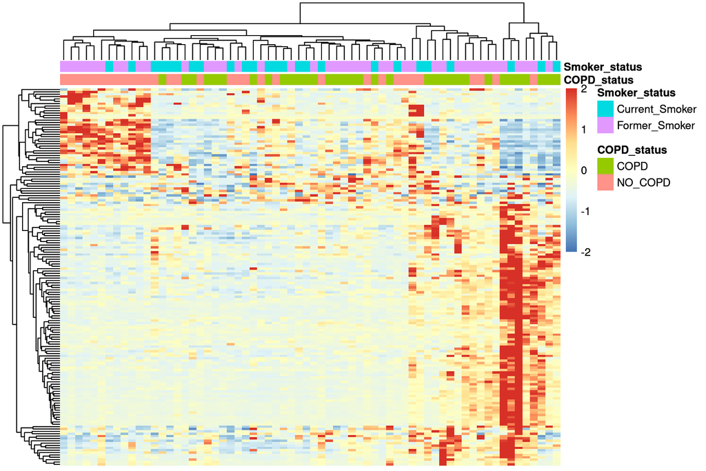

```r
counts.z <- t(scale(t(counts)))
counts.z.trim <- counts.z

counts.z.trim[counts.z.trim < -2] <- -2
counts.z.trim[counts.z.trim > 2] <- 2

counts.z.trim <- counts.z.trim[rownames(counts.z.trim) %in% rownames(resSig),]

COPD_status <- annotNasal$COPD_status
Smoker_status <- annotNasal$GRPB_SMK_STS

annotation_col <- data.frame(COPD_status, Smoker_status)
rownames(annotation_col) <- colnames(counts.z.trim)
callback <- function(hc, mat) {
  sv <- svd(t(mat))$v[, 1]
  dend <- reorder(as.dendrogram(hc), wts = sv)
  as.hclust(dend)
}

out <- pheatmap(counts.z.trim,
  color = colorRampPalette(rev(brewer.pal(n = 7, name = "RdYlBu")))(100),
  annotation_col = annotation_col,
  legend = T,
  show_rownames = F,
  show_colnames = F,
  fontsize_row = 9,
  cluster_rows = TRUE,
  cluster_cols = TRUE
)

out
```

### Violin Plots

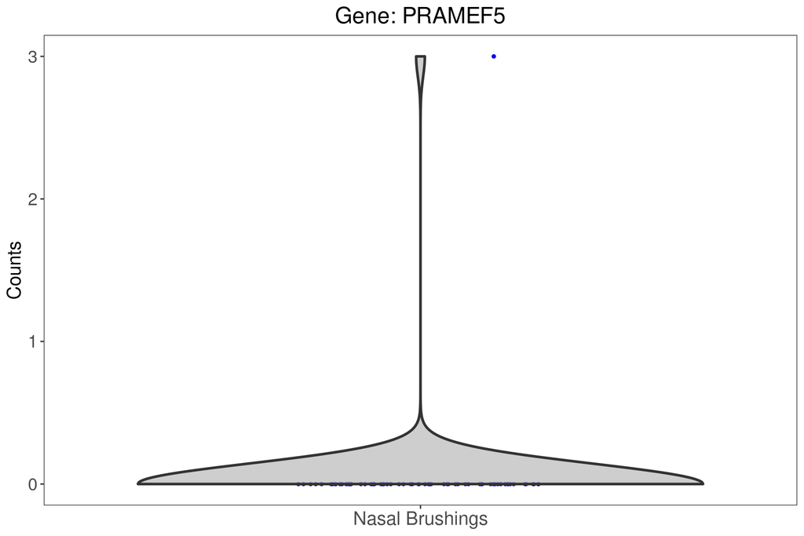

```r
dots <- T
boxplot <- F
violin <- T

df <- data.frame(
  x = annotNasal$`Sample Type`,
  y = counts["PRAMEF5",]
)

p <- ggplot2::ggplot(df) +
  ggplot2::aes_string(
    x = "x",
    y = "y"
  )
if (dots == TRUE) {
  p <- p + ggplot2::geom_jitter(
    color = "blue",
    width = 0.2,
    height = 0,
    size = 1,
    alpha = 1
  )
}
if (boxplot == TRUE) {
  p <- p + ggplot2::geom_boxplot(
    width = 0.5,
    alpha = 0
  )
}
if (violin == TRUE) {
  p <- p + ggplot2::geom_violin(
    trim = TRUE,
    scale = "width",
    size = 1,
    fill = "grey",
    alpha = 0.75
  )
}

p <- p + ggplot2::theme_bw() +
  ggplot2::theme(
    panel.grid.major = ggplot2::element_blank(),
    panel.grid.minor = ggplot2::element_blank(),
    axis.text = ggplot2::element_text(size = 14),
    axis.title = ggplot2::element_text(size = 10)
  ) + ggplot2::theme(axis.text.x = ggplot2::element_text(size = 15)) +
  ggplot2::ylab("Counts") +
  ggplot2::theme(
    axis.title.y = element_text(size = 15),
    axis.title.x = ggplot2::element_blank()
  )

p <- p + ggplot2::ggtitle(label = "Gene: PRAMEF5") +
  ggplot2::theme(plot.title = ggplot2::element_text(
    hjust = 0.5,
    size = 18
  ))

p
```

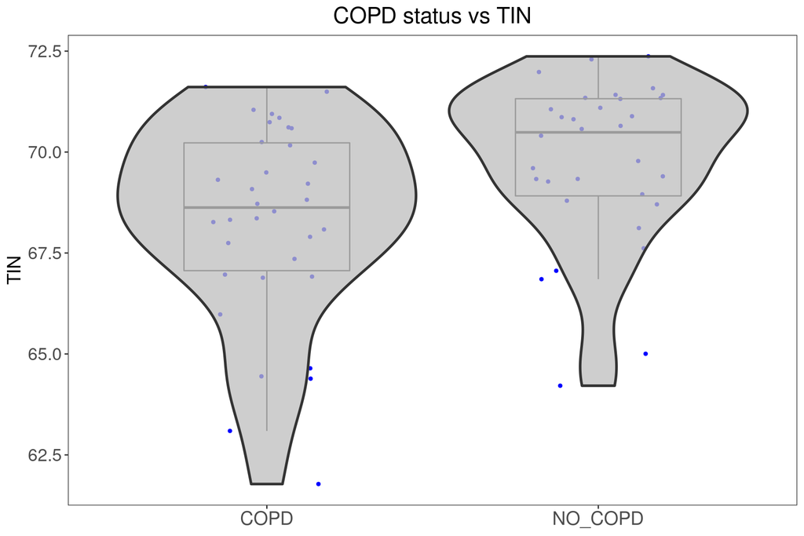

```r
dots <- T
boxplot <- T
violin <- T

df <- data.frame(
  x = annotNasal$COPD_status,
  y = annotNasal$TIN
)

p <- ggplot2::ggplot(df) +
  ggplot2::aes_string(
    x = "x",
    y = "y"
  )
if (dots == TRUE) {
  p <- p + ggplot2::geom_jitter(
    color = "blue",
    width = 0.2,
    height = 0,
    size = 1,
    alpha = 1
  )
}
if (boxplot == TRUE) {
  p <- p + ggplot2::geom_boxplot(
    width = 0.5,
    alpha = 0
  )
}
if (violin == TRUE) {
  p <- p + ggplot2::geom_violin(
    trim = TRUE,
    scale = "width",
    size = 1,
    fill = "grey",
    alpha = 0.75
  )
}

p <- p + ggplot2::theme_bw() +
  ggplot2::theme(
    panel.grid.major = ggplot2::element_blank(),
    panel.grid.minor = ggplot2::element_blank(),
    axis.text = ggplot2::element_text(size = 14),
    axis.title = ggplot2::element_text(size = 10)
  ) + ggplot2::theme(axis.text.x = ggplot2::element_text(size = 15)) +
  ggplot2::ylab("TIN") +
  ggplot2::theme(
    axis.title.y = element_text(size = 15),
    axis.title.x = ggplot2::element_blank()
  )

p <- p + ggplot2::ggtitle(label = "COPD status vs TIN") +
  ggplot2::theme(plot.title = ggplot2::element_text(
    hjust = 0.5,
    size = 18
  ))

p
```

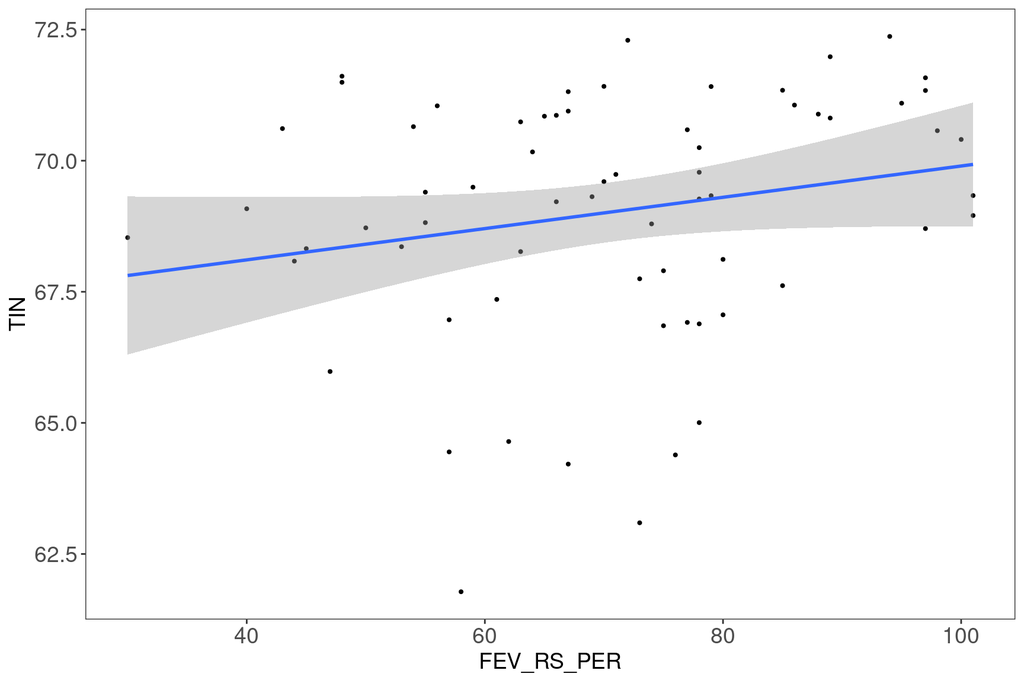

```r
df <- data.frame(x = annotNasal$FEV_RS_PER, y = annotNasal$TIN)
lm_eqn <- function(df){
  # browser()
  m <- lm(y ~ x, df)
  a <- coef(m)[1]
  a <- ifelse(sign(a) >= 0,
              paste0(" + ", format(a, digits = 4)),
              paste0(" - ", format(-a, digits = 4))  )
  eq1 <- substitute( paste( italic(y) == b, italic(x), a ),
                     list(a = a,
                          b = format(coef(m)[2], digits = 4)))
  eq2 <- substitute( paste( italic(R)^2 == r2 ),
                     list(r2 = format(summary(m)$r.squared, digits = 3)))
  c( as.character(as.expression(eq1)), as.character(as.expression(eq2)))
}

labels <- lm_eqn(df)


ggplot(annotNasal, aes(x = FEV_RS_PER, y = TIN)) +
  geom_point(size = 0.75) +
  ggplot2::theme_bw() +
  ggplot2::theme(
    panel.grid.major = ggplot2::element_blank(),
    panel.grid.minor = ggplot2::element_blank(),
    axis.text = ggplot2::element_text(size = 14),
    axis.title = ggplot2::element_text(size = 14)
  ) +
  ggplot2::theme(legend.title = ggplot2::element_text(size = 15), legend.text = ggplot2::element_text(size = 13)) +
  ggplot2::guides(
    colour =
      ggplot2::guide_legend(override.aes = list(size = 2))
  ) + geom_smooth(method=lm)+
  geom_text(x = 75, y = 90, label = labels[1], parse = TRUE,  check_overlap = TRUE )
```

```r
#
#   geom_point(data = resSig, aes(x = log2FoldChange, y = nLogPVal), color = "Red")+
#   ggplot2::labs(y = "-log10(Adjusted p-value)") +
#   ggplot2::ggtitle(label = "COPD status") +
#   ggplot2::theme(plot.title = ggplot2::element_text(
#     hjust = 0.5,
#     size = 18
#   ))
```

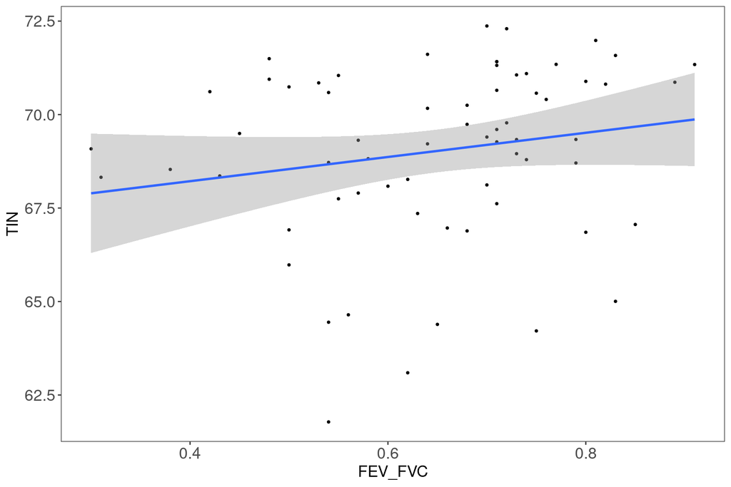

```r
df <- data.frame(x = annotNasal$FEV_FVC, y = annotNasal$TIN)
lm_eqn <- function(df){
  # browser()
  m <- lm(y ~ x, df)
  a <- coef(m)[1]
  a <- ifelse(sign(a) >= 0,
              paste0(" + ", format(a, digits = 4)),
              paste0(" - ", format(-a, digits = 4))  )
  eq1 <- substitute( paste( italic(y) == b, italic(x), a ),
                     list(a = a,
                          b = format(coef(m)[2], digits = 4)))
  eq2 <- substitute( paste( italic(R)^2 == r2 ),
                     list(r2 = format(summary(m)$r.squared, digits = 3)))
  c( as.character(as.expression(eq1)), as.character(as.expression(eq2)))
}

labels <- lm_eqn(df)


ggplot(annotNasal, aes(x = FEV_FVC, y = TIN)) +
  geom_point(size = 0.75) +
  ggplot2::theme_bw() +
  ggplot2::theme(
    panel.grid.major = ggplot2::element_blank(),
    panel.grid.minor = ggplot2::element_blank(),
    axis.text = ggplot2::element_text(size = 14),
    axis.title = ggplot2::element_text(size = 14)
  ) +
  ggplot2::theme(legend.title = ggplot2::element_text(size = 15), legend.text = ggplot2::element_text(size = 13)) +
  ggplot2::guides(
    colour =
      ggplot2::guide_legend(override.aes = list(size = 2))
  ) + geom_smooth(method=lm)+
  geom_text(x = 75, y = 90, label = labels[1], parse = TRUE,  check_overlap = TRUE )
```

```r
#
#   geom_point(data = resSig, aes(x = log2FoldChange, y = nLogPVal), color = "Red")+
#   ggplot2::labs(y = "-log10(Adjusted p-value)") +
#   ggplot2::ggtitle(label = "COPD status") +
#   ggplot2::theme(plot.title = ggplot2::element_text(
#     hjust = 0.5,
#     size = 18
#   ))
```

### Tables

#### Differentially expressed in COPD patients

```r
resSigDown <- resSig[resSig$log2FoldChange < -0.5, ]
resSigDown <- resSigDown[order(resSigDown$log2FoldChange, decreasing = F),]
resSigDown <- resSigDown[,c(2,5,6)]
colnames(resSigDown) <- c("Log2FC", "P-value", "Adj. P-value")
resSigDown %>%
  knitr::kable(
    format = "html", align = rep("c", ncol(resSig) + 1),
    row.names = TRUE
  ) %>%
  kableExtra::kable_styling() %>%
  kableExtra::scroll_box(height = "300px")
```

|  | Log2FC | P-value | Adj. P-value |
| --- | --- | --- | --- |
| RP11-284F21.8 | -3.4366271 | 0.0003856 | 0.0488336 |
| SLC9A3 | -2.7644155 | 0.0000000 | 0.0000285 |
| CTB-60E11.4 | -2.6257165 | 0.0000162 | 0.0231880 |
| RP3-322G13.7 | -2.4442097 | 0.0000017 | 0.0070272 |
| SEMG1 | -2.1524778 | 0.0001632 | 0.0394636 |
| CCDC147-AS1 | -2.1497811 | 0.0001330 | 0.0391739 |
| C11orf96 | -2.1054201 | 0.0000382 | 0.0291808 |
| HCAR2 | -2.0570510 | 0.0000001 | 0.0007744 |
| S100A7 | -2.0394122 | 0.0002104 | 0.0394636 |
| PLEK | -2.0174676 | 0.0002118 | 0.0394636 |
| PITX2 | -1.9956249 | 0.0002009 | 0.0394636 |
| NCR1 | -1.9853003 | 0.0003331 | 0.0459045 |
| RN7SL336P | -1.9573763 | 0.0001741 | 0.0394636 |
| SLC26A4 | -1.9171732 | 0.0000483 | 0.0311345 |
| RP11-22N19.2 | -1.9052195 | 0.0001013 | 0.0352238 |
| RP11-61J19.4 | -1.8990794 | 0.0000253 | 0.0241081 |
| RP11-293M10.5 | -1.8851646 | 0.0002097 | 0.0394636 |
| GPR65 | -1.8729214 | 0.0003668 | 0.0480020 |
| CHI3L1 | -1.8545784 | 0.0000371 | 0.0291808 |
| PHACTR1 | -1.8501102 | 0.0000908 | 0.0326191 |
| AP000769.1 | -1.8468643 | 0.0000827 | 0.0319178 |
| TNIP3 | -1.8041944 | 0.0000672 | 0.0319178 |
| TAGAP | -1.7765363 | 0.0001356 | 0.0391739 |
| PTGS2 | -1.7649684 | 0.0001839 | 0.0394636 |
| RP1-13D10.2 | -1.7496581 | 0.0001498 | 0.0394636 |
| ADRA2B | -1.7236670 | 0.0000291 | 0.0254946 |
| AFF2 | -1.7159228 | 0.0000851 | 0.0319178 |
| ZNF8 | -1.7066420 | 0.0000527 | 0.0319178 |
| CSF3 | -1.6988066 | 0.0002093 | 0.0394636 |
| RP11-290F20.1 | -1.6928851 | 0.0000435 | 0.0304315 |

[output cut: 93 more lines]

#### Differentially expressed in non-COPD patients

```r
resSigUp <- resSig[resSig$log2FoldChange > 0.5, ]
resSigUp <- resSigUp[order(resSigUp$log2FoldChange, decreasing = T),]
resSigUp <- resSigUp[,c(2,5,6)]
colnames(resSigUp) <- c("Log2FC", "P-value", "Adj. P-value")
resSigUp %>%
  knitr::kable(
    format = "html", align = rep("c", ncol(resSig) + 1),
    row.names = TRUE
  ) %>%
  kableExtra::kable_styling() %>%
  kableExtra::scroll_box(height = "300px")
```

|  | Log2FC | P-value | Adj. P-value |
| --- | --- | --- | --- |
| UCHL1 | 2.4253860 | 0.0000002 | 0.0011729 |
| FN1 | 2.0813733 | 0.0000132 | 0.0231880 |
| LINC01138 | 1.7775315 | 0.0004780 | 0.0489435 |
| PAMR1 | 1.7074173 | 0.0001282 | 0.0391739 |
| COL1A2 | 1.5869486 | 0.0003138 | 0.0451190 |
| SSUH2 | 1.5169213 | 0.0002515 | 0.0403735 |
| PCSK1N | 1.4599584 | 0.0001373 | 0.0391739 |
| BTNL9 | 1.4480843 | 0.0001961 | 0.0394636 |
| ST6GALNAC5 | 1.2760349 | 0.0001246 | 0.0391739 |
| C3orf30 | 1.2497453 | 0.0001952 | 0.0394636 |
| COL6A3 | 1.2344867 | 0.0003151 | 0.0451190 |
| AC079610.2 | 1.1572872 | 0.0000165 | 0.0231880 |
| EEF1A1P13 | 1.1458691 | 0.0003267 | 0.0453770 |
| CYP11A1 | 1.1451178 | 0.0003974 | 0.0489066 |
| LRP2 | 1.0681798 | 0.0000458 | 0.0304315 |
| ARSH | 0.9690142 | 0.0003642 | 0.0480020 |
| NXF3 | 0.9473503 | 0.0003964 | 0.0489066 |
| FOXD4 | 0.9424142 | 0.0003732 | 0.0481011 |
| PAPPA2 | 0.9174271 | 0.0000223 | 0.0231880 |
| HSPA12A | 0.8319153 | 0.0004592 | 0.0489066 |
| RTN3P1 | 0.7566129 | 0.0001509 | 0.0394636 |
| COL5A2 | 0.7410100 | 0.0000274 | 0.0249972 |
| AGBL3 | 0.7287293 | 0.0004625 | 0.0489066 |
| RP11-430B1.2 | 0.6950816 | 0.0001642 | 0.0394636 |
| C9orf66 | 0.6913652 | 0.0000090 | 0.0231880 |
| RP11-816J6.3 | 0.6802200 | 0.0001659 | 0.0394636 |
| PLTP | 0.6660169 | 0.0001344 | 0.0391739 |
| RP11-66N11.8 | 0.6524849 | 0.0002199 | 0.0394636 |
| RP11-572C15.6 | 0.6372749 | 0.0004746 | 0.0489435 |
| CCDC80 | 0.6224054 | 0.0000699 | 0.0319178 |
| NPAS1 | 0.5667530 | 0.0000840 | 0.0319178 |
| KLHL35 | 0.5578197 | 0.0003637 | 0.0480020 |
| RP11-293M10.6 | 0.5236191 | 0.0004345 | 0.0489066 |
| IDNK | 0.5144980 | 0.0004455 | 0.0489066 |
| PLA2G10 | 0.5118208 | 0.0000332 | 0.0279802 |
| C6orf164 | 0.5026684 | 0.0004231 | 0.0489066 |

### Checking for overlap between COPD signature

Differentially expressed genes were checked for overlap with the 98 genes from the COPD signature from [Steiling et al, 2013](https://pubmed.ncbi.nlm.nih.gov/23471465/)

```r
#Preprocessing. Run ahead of time and comment out when knitting Rmd
names(steilingGenes) <- "Names"
steilingSignature <- steilingGenes$Names
steilingUp <- head(steilingSignature,54)

#create mart object, this is for homo sapiens

mart <- useMart(biomart = "ensembl", dataset = "hsapiens_gene_ensembl")

upBM <- getBM(filters= "hgnc_symbol", attributes= c("ensembl_gene_id","hgnc_symbol"),values=steilingUp,mart= mart)

upBM <- upBM[upBM$ensembl_gene_id %in% rownames(assay(seNasal)),]
# write.table(upBM$ensembl_gene_id, "20201102_SteilingUp_Genelist.grp", sep = "\t", quote = F, col.names = F, row.names = F)
steilingDown <- tail(steilingSignature,44)

downBM <- getBM(filters= "hgnc_symbol", attributes= c("ensembl_gene_id","hgnc_symbol"),values=steilingDown,mart= mart)
downBM <- downBM[-32,]
# write.table(downBM$ensembl_gene_id, "20201102_SteilingDown_Genelist.grp", sep = "\t", quote = F, col.names = F, row.names = F)

#Send to GSEA 11/3/2020


#Check for overlap:
upoverlap <- sum(downBM$hgnc_symbol %in% rownames(resSigUp))
upoverlapgenes <- downBM$hgnc_symbol[downBM$hgnc_symbol %in% rownames(resSigUp)]
downoverlap <- sum(upBM$hgnc_symbol %in% rownames(resSigDown))
downoverlapgenes <- upBM$hgnc_symbol[upBM$hgnc_symbol %in% rownames(resSigDown)]
```

Overall, of the 54 genes associated with increase of COPD status in the Steiling signature, 5 were differentially expressed in patients considered to be of COPD status. These are: MTNR1A, PTGS2, SAA1, SAA2, SLC26A4.

Of the 44 genes associated with decrease of COPD status in the Steiling signature, 1 were differentially expressed in patients considered to be of COPD status. These are: LRP2.